# Mars Weather Model

## Pre-processing the Data

In order for the model to be accurate in its predictions, it will need to be fed clean and pre-processed data. This section of the notebook will focus on reading the data from the CSV file and cleaning the data so that only required data is fed into the model so that it can be trained to give an accurate output.

```python
# Importing the required libraries.
import numpy as np
import pandas as pd
pd.options.mode.chained_assignment = None

# Reading the CSV file.
data = pd.read_csv("data.csv")
data.head()
```

|  | id | terrestrial_date | sol | ls | month | min_temp | max_temp | pressure | wind_speed | atmo_opacity |
| --- | --- | --- | --- | --- | --- | --- | --- | --- | --- | --- |
| 0 | 1895 | 2018-02-27 | 1977 | 135 | Month 5 | -77.0 | -10.0 | 727.0 | NaN | Sunny |
| 1 | 1893 | 2018-02-26 | 1976 | 135 | Month 5 | -77.0 | -10.0 | 728.0 | NaN | Sunny |
| 2 | 1894 | 2018-02-25 | 1975 | 134 | Month 5 | -76.0 | -16.0 | 729.0 | NaN | Sunny |
| 3 | 1892 | 2018-02-24 | 1974 | 134 | Month 5 | -77.0 | -13.0 | 729.0 | NaN | Sunny |
| 4 | 1889 | 2018-02-23 | 1973 | 133 | Month 5 | -78.0 | -18.0 | 730.0 | NaN | Sunny |

The summary table above shows us which columns need to be dropped in order for the data to be in a good format for the model to be processed with. For the purpose of this prediction model, the following columns will be dropped:

1. id
2. sol
3. ls
4. month
5. min_temp
6. pressure
7. wind_speed
8. atmo_opacity

This is because the prediction model will focus primarily on the terrestrial date and the max temperature of Mars at that date. The other columns will simply pollute the date and give us a less accurate prediction.

```python
# Dropping the unnecessary columns
raw_data = data.drop(columns=["id", "sol", "ls", "month", "min_temp", "pressure", "wind_speed", "atmo_opacity"])
raw_data.info()
```

```
<class 'pandas.core.frame.DataFrame'>
RangeIndex: 1894 entries, 0 to 1893
Data columns (total 2 columns):
 #   Column            Non-Null Count  Dtype
---  ------            --------------  -----
 0   terrestrial_date  1894 non-null   object
 1   max_temp          1867 non-null   float64
dtypes: float64(1), object(1)
memory usage: 29.7+ KB
```

Once these columns have been dropped, we can now take a look at the information of the entries that are in the table. It can be seen from the information above that there are null values in the max_temp columns. These rows need to be removed as part of the cleaning process in order for the model to produce the best results

```python
cleaned_data = raw_data.dropna()
cleaned_data.info()
```

```
<class 'pandas.core.frame.DataFrame'>
Int64Index: 1867 entries, 0 to 1891
Data columns (total 2 columns):
 #   Column            Non-Null Count  Dtype
---  ------            --------------  -----
 0   terrestrial_date  1867 non-null   object
 1   max_temp          1867 non-null   float64
dtypes: float64(1), object(1)
memory usage: 43.8+ KB
```

Now the null values have been removed but we can see from the figure above there is also another problem. The terrestrial date column currently holds the date in the form of an object, which cannot be processed by the model. In order to be fed through to the model with no issues, the data values in this column need to be converted to datetime objects so that the model can understand and process the data.

```python
cleaned_data["terrestrial_date"] = pd.to_datetime(cleaned_data.terrestrial_date, format = "%Y-%m-%d")
cleaned_data.info()
```

```
<class 'pandas.core.frame.DataFrame'>
Int64Index: 1867 entries, 0 to 1891
Data columns (total 2 columns):
 #   Column            Non-Null Count  Dtype
---  ------            --------------  -----
 0   terrestrial_date  1867 non-null   datetime64[ns]
 1   max_temp          1867 non-null   float64
dtypes: datetime64[ns](1), float64(1)
memory usage: 43.8 KB
```

Now the data is in a format that can easily be processed by the model.

## Vizualising the Current Data

At this point we can plot the current data on a graph to visualize how the current data looks and the effect the date has on the max temperature of Mars.

[figure not shown]

```python
# Importing the required libraries.
import matplotlib.pyplot as plt
%matplotlib inline
from matplotlib.pylab import rcParams
rcParams["figure.figsize"] = 20, 5

# Plotting the current data.
plt.plot(cleaned_data["max_temp"], label = "Mars Temperature History")
plt.title("Mars Weather")
plt.xlabel("Terrestrial Date")
plt.ylabel("Maximum Temperature (°C)")
plt.show()
```

The figure above indicates that the temperature on Mars follows a cyclical pattern depending on the time of year, which is very similar to how it is on Earth. This data can then be used to predict what the max temperature will be in the coming years.

## Training the Model

This section of the notebook will focus on training the model. For the purpose of this project, we will use the LSTM Prediction Model as this is a good model to use when you want to make predictions based on time-series datasets.

```python
# Importing the required libraries.
import tensorflow as tf
from tensorflow import keras
from keras.models import Sequential
from keras.layers import LSTM, Dense
from sklearn.preprocessing import MinMaxScaler
from sklearn.model_selection import train_test_split
```

```python
# Preparing the data.
cleaned_data.index = cleaned_data["terrestrial_date"]
cleaned_data = cleaned_data.sort_index(ascending = True, axis = 0)
data = pd.DataFrame(index = range(0, len(cleaned_data)), columns = ["terrestrial_date", "max_temp"])

for i in range(0, len(data)):
    data["terrestrial_date"][i] = cleaned_data["terrestrial_date"][i]
    data["max_temp"][i] = cleaned_data["max_temp"][i]
```

```python
# Splitting the data into training and testing data, and then scaling the data using a min-max scaler.
data.index = data.terrestrial_date
data.drop("terrestrial_date", axis = 1, inplace = True)

final_data = data.values
train_data = final_data[0:1300, :]
valid_data = final_data[1300:, :]

scaler = MinMaxScaler(feature_range = (0, 1))

scaled_data = scaler.fit_transform(final_data)
x_train, y_train = [], []
for i in range(60, len(train_data)):
    x_train.append(scaled_data[i - 60:i, 0])
    y_train.append(scaled_data[i, 0])

x_train = np.asarray(x_train)
y_train = np.asarray(y_train)
```

```python
# Using the LSTM prediction model.
lstm_model = Sequential()
lstm_model.add(LSTM(units = 50, return_sequences = True, input_shape = (np.shape(x_train)[1], 1)))
lstm_model.add(LSTM(units = 50))
lstm_model.add(Dense(1))

model_data = data[len(data) - len(valid_data) - 60:].values
model_data = model_data.reshape(-1, 1)
model_data = scaler.transform(model_data)

lstm_model.compile(loss = "mean_squared_error", optimizer = "adam", metrics=["MeanSquaredError", "AUC"])
lstm_model.fit(x_train, y_train, epochs = 10, batch_size = 5, verbose = 1)

x_test = []
for i in range(60, model_data.shape[0]):
    x_test.append(model_data[i - 60:i, 0])

x_test = np.array(x_test)
x_test = np.reshape(x_test, (x_test.shape[0], x_test.shape[1], 1))

predicted_max_temp = lstm_model.predict(x_test)
predicted_max_temp = scaler.inverse_transform(predicted_max_temp)
```

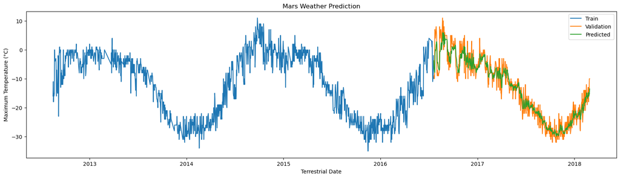

```python
# Plotting the data from the model onto a graph.
train_data = data[:1300]
valid_data = data[1300:]
valid_data["Predictions"] = predicted_max_temp
plt.plot(train_data["max_temp"])
plt.plot(valid_data[["max_temp", "Predictions"]])
plt.title("Mars Weather Prediction")
plt.xlabel("Terrestrial Date")
plt.ylabel("Maximum Temperature (°C)")
plt.legend(["Train", "Validation", "Predicted"])
plt.show()
```

The graph above demonstrates the accuracy of the LSTM model that has been created for the purpose of this project. The line in blue is the data that the model has been trained on. The orange line is the data that has been used as validation for the model (in other words the testing data). The green line is the predicted values that the model has generated. This graph can be used to visualize the accuracy of the model, and it can be seen that the model is quite accurate with how the green line has followed the orange line quite closely.